# Evidence at Clearance and Safety After: Clinical Validation and Recalls of FDA-Authorized AI Medical Devices

90-819 Python Programming II · Final Project

Author

Abdullah Arshad

Published

October 9, 2026

1,521

AI devices analyzed

103

recalled after clearance (6.8%)

4.2×

odds of recall without reported clinical validation

0.83

AUC of the recall model

Download the PDF version

## 1. Question

Nearly all of the 1,600+ AI-enabled devices the FDA has authorized were cleared through the 510(k) pathway, which requires “substantial equivalence” to an existing device but no testing on patients. This project asks: **are AI devices cleared without reported clinical validation recalled more often, or reported for more adverse events, than devices backed by clinical testing?** It extends a 2025 *JAMA Health Forum* recall study of 950 devices[^1] to all 1,614 devices on the FDA’s list, and adds adverse event reports.

<sup>1</sup> *JAMA Health Forum* (2025). Recalls of FDA-cleared AI-enabled medical devices (950 devices, 60 with recalls). https://jamanetwork.com/journals/jama-health-forum/fullarticle/2837802. Related work: *PLOS Digital Health* (2026), https://www.ncbi.nlm.nih.gov/pmc/articles/PMC13489462/; *Lancet Digital Health* (2023), https://www.thelancet.com/journals/landig/article/PIIS2589-7500(23)00126-7/fulltext.

## 2. Data

One row per device was built from seven public sources, pulled on 2026-10-05 and joined in SQLite on the FDA submission number or product code:

| Source | Access | What it provides |
| --- | --- | --- |
| FDA AI-Enabled Medical Device List[^2] | CSV download | Base table: decision date, company, specialty panel, product code |
| FDA 510(k) clearance file (`pmn96cur`)[^3] | Bulk download | Date received (review time) |
| openFDA device classification[^4] | Bulk JSON | Risk class |
| openFDA PMA, recall and enforcement APIs | REST API | PMA dates; recalls and recall dates |
| openFDA MAUDE adverse events | REST API | Adverse event reports per device |
| 510(k), De Novo and PMA summaries[^5] | Web scraping (1,605 PDFs) | Whether the sponsor reported clinical validation |
| SEC EDGAR company tickers[^6] | JSON download | Public company status |

<sup>2</sup> U.S. FDA, Artificial Intelligence-Enabled Medical Devices list, https://www.fda.gov/medical-devices/software-medical-device-samd/artificial-intelligence-enabled-medical-devices, downloaded 2026-10-05.

<sup>3</sup> U.S. FDA, Downloadable 510(k) Files, `pmn96cur.zip`, https://www.fda.gov/medical-devices/510k-clearances/downloadable-510k-files.

<sup>4</sup> openFDA device endpoints (classification, PMA, recall, enforcement, event), https://open.fda.gov/apis/device/. openFDA refreshes weekly; pull dates are recorded in `data/raw/MANIFEST.csv`.

<sup>5</sup> FDA 510(k), De Novo and PMA summary documents, https://www.accessdata.fda.gov/scripts/cdrh/cfdocs/cfpmn/pmn.cfm.

<sup>6</sup> U.S. SEC EDGAR, `company_tickers.json`, https://www.sec.gov/files/company_tickers.json.

## 3. Feature engineering and selection

**Key variable: clinical validation.** A device counts as *clinically validated* if its summary reports testing on patients or patient data with a performance result, such as sensitivity or agreement with a reference standard. The testing section of each summary was extracted with `pdfplumber`[^7] and classified by Claude (Anthropic), which quoted its evidence for every decision.[^8] On 100 summaries I hand-coded blind to its output, it agreed 90.4% of the time (Cohen’s κ = 0.80),[^9] against κ = 0.61 for a keyword classifier.

<sup>7</sup> Analysis in Python with pandas, SQLite, pdfplumber (Singer-Vine, https://github.com/jsvine/pdfplumber), statsmodels (Seabold, S., & Perktold, J. (2010). Statsmodels: Econometric and statistical modeling with Python. *Proceedings of the 9th Python in Science Conference*, 92–96), lifelines (Davidson-Pilon, C. (2019). lifelines: survival analysis in Python. *Journal of Open Source Software*, 4(40), 1317), scikit-learn and matplotlib.

<sup>8</sup> Clinical validation was coded by Claude Sonnet 5 (Anthropic), run as parallel subagents in Claude Code in October 2026. The full prompt is in `src/05b_llm_batches.py`; every decision and supporting quote is in `data/interim/validation_llm.csv`. Claude (Opus 5.5) also assisted with writing the analysis code and drafting this report, under the course’s Tier 4 GenAI policy.

<sup>9</sup> Cohen, J. (1960). A coefficient of agreement for nominal scales. *Educational and Psychological Measurement*, 20(1), 37–46.

**Outcomes.** *Recalled*: any recall that began on or after authorization (earlier recalls of an older product line were excluded for 7 devices). *Adverse events*: the count of MAUDE reports.

**Controls**, set in the analysis plan as factors that could drive both evidence and outcomes:

- **Risk class** (class III vs. other; 99% are class II): higher-risk devices get stricter review and closer monitoring.
- **Specialty** (radiology, cardiovascular, neurology, other): evidence norms and reporting volume differ by field.
- **Public company**: large firms sell more units and recall and report more, as the *JAMA* study found. Assigned by exact matching of normalized names to SEC registrants plus a table of parent companies; fuzzy matching produced only false pairs and was rejected.
- **Review time** (days from receipt to decision): a proxy for how complex the submission was.
- **Years on market**: older devices have had more time to be recalled or reported.

**Sample.** PMA supplements were excluded because their recall and MAUDE records are filed under the base PMA (one AI feature inherited over 42,000 reports for a whole defibrillator line), as were 89 devices with no usable summary text. The model sample has **1,521 devices**, 103 of them recalled.

The raw gap is large (Figure 1), but the groups also differ on the controls: devices without validation have been on the market longer and come more often from public companies (Table 1).

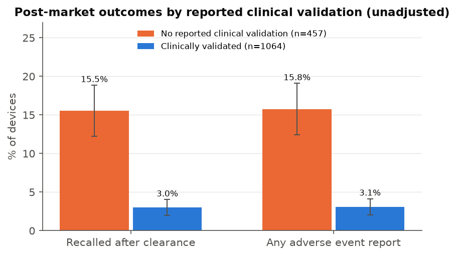

Figure 1: Unadjusted post-market outcomes by reported clinical validation (95% CI).

Table 1: Characteristics of the model sample by reported clinical validation.

|  | No reported validation | Clinically validated | All |
| --- | --- | --- | --- |
| Devices | 457 | 1,064 | 1,521 |
| Recalled, % | 15.5 | 3.0 | 6.8 |
| Any adverse event report, % | 15.8 | 3.1 | 6.9 |
| Adverse event reports, total | 1,051 | 1,320 | 2,371 |
| Public company, % | 54.3 | 30.8 | 37.9 |
| Radiology, % | 72.4 | 78.7 | 76.8 |
| Risk class III, % | 0.0 | 0.6 | 0.4 |
| Review time, median days | 116 | 152 | 139 |
| Years on market, mean | 4.4 | 3.3 | 3.7 |

## 4. Models

- **Recall** (yes/no): logistic regression.[^10]
- **Adverse events** (counts): negative binomial regression with an offset of log(years on market), so it compares reports per year. Poisson was rejected: dispersion 92 (1 expected), AIC 16,299 vs. 1,351.[^11]
- **Robustness:** a Cox model of time to first recall,[^12] since newer devices have had less time to be recalled, and standard errors clustered by company, since one recall can cover several of a firm’s devices.[^13]

<sup>10</sup> Hosmer, D. W., Lemeshow, S., & Sturdivant, R. X. (2013). *Applied Logistic Regression* (3rd ed.). Wiley.

<sup>11</sup> Cameron, A. C., & Trivedi, P. K. (2013). *Regression Analysis of Count Data* (2nd ed.). Cambridge University Press.

<sup>12</sup> Cox, D. R. (1972). Regression models and life-tables. *Journal of the Royal Statistical Society, Series B*, 34(2), 187–220.

<sup>13</sup> Cameron, A. C., & Miller, D. L. (2015). A practitioner’s guide to cluster-robust inference. *Journal of Human Resources*, 50(2), 317–372.

## 5. Evaluation

Table 2: Model performance.

| Model | Metric | Value |
| --- | --- | --- |
| Recall: logistic | AUC (ROC) | 0.83 (without validation: 0.79) |
|  | McFadden pseudo-R² | 0.19 |
|  | Brier score | 0.056 (base-rate model: 0.063) |
|  | LR test, validation (1 df) | χ² = 39.2, p < 0.001 |
| Time to recall: Cox | Concordance (Harrell’s C) | 0.80 |
|  | PH assumption test | p = 0.15 |
| Adverse events: neg. binomial | AIC | 1,351 (Poisson: 16,299) |
|  | McFadden pseudo-R² | 0.05 |

The recall model discriminates well (AUC[^14] 0.83; Cox concordance[^15] 0.80), and adding validation raises the AUC from 0.79, so validation carries information beyond the controls. Its predicted probabilities improve only modestly on the base rate (Brier score), as expected when only 7% of devices are recalled. The Cox model’s proportional-hazards assumption holds. The adverse event model explains little (McFadden pseudo-R²[^16] 0.05), since 93% of devices have no reports.

<sup>14</sup> Hanley, J. A., & McNeil, B. J. (1982). The meaning and use of the area under a receiver operating characteristic (ROC) curve. *Radiology*, 143(1), 29–36.

<sup>15</sup> Harrell, F. E., Califf, R. M., Pryor, D. B., Lee, K. L., & Rosati, R. A. (1982). Evaluating the yield of medical tests. *JAMA*, 247(18), 2543–2546.

<sup>16</sup> McFadden, D. (1974). Conditional logit analysis of qualitative choice behavior. In P. Zarembka (Ed.), *Frontiers in Econometrics* (pp. 105–142). Academic Press.

## 6. Results and interpretation

Table 3: Adjusted associations with post-market outcomes (estimate, 95% CI). All models include risk class, specialty, public company status and review time; the logistic model also includes years on market, which the other two models handle as time at risk.

|  | Recall, odds ratio | Time to recall, hazard ratio | Adverse event rate ratio |
| --- | --- | --- | --- |
| Clinically validated | 0.24 (0.15–0.38) | 0.28 (0.18–0.43) | 0.56 (0.26–1.18) |
| Public company | 6.24 (3.61–10.77) | 5.50 (3.29–9.21) | 29.06 (12.72–66.35) |

**Recalls.** Validated devices had 76% lower odds of recall (odds ratio 0.24 (95% CI 0.15–0.38)): devices **without** reported validation had about 4.2 times the odds. Company-clustered errors (95% CI 0.14–0.40) and the Cox model agree, and the recall curves separate within the first year (Figure 2).[^17] Public companies’ devices also had far higher odds of recall (6.2), close to the *JAMA* estimate of 5.9.

<sup>17</sup> Kaplan, E. L., & Meier, P. (1958). Nonparametric estimation from incomplete observations. *Journal of the American Statistical Association*, 53(282), 457–481.

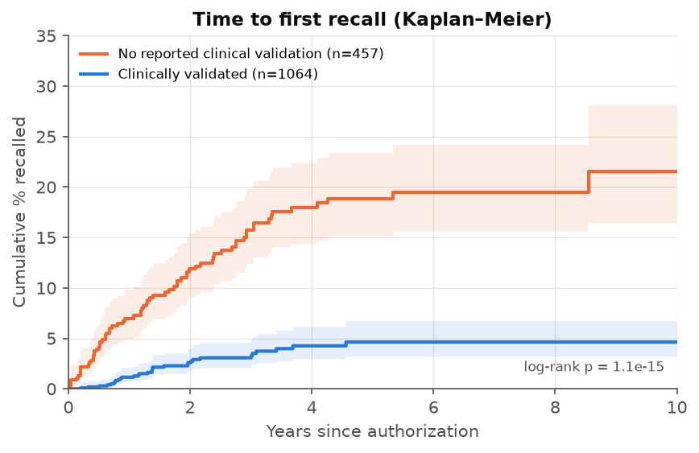

Figure 2: Cumulative share of devices recalled since authorization (Kaplan–Meier, 95% CI).

**Adverse events.** The adjusted rate was lower for validated devices, but the interval includes 1; specialty and company type account for most of the raw gap.

**Limitations.** This is an association, not a causal effect: unvalidated devices are often AI features on CT, MRI and ultrasound platforms whose recalls may involve the hardware. Recalls are rare (103 events). MAUDE counts reflect reporting behavior as well as harm. The coding depends on what sponsors wrote and disagreed with hand-coding on about 1 in 10 devices. The FDA list is not comprehensive, and public status is as of the pull date.

**Implication.** Even after adjustment, AI devices cleared without reported testing on patient data had about four times the odds of recall, and about 22% of recent clearances still report none. This supports requiring, or at least publicly reporting, clinical testing before 510(k) clearance.

## Data and code

Code, raw and cleaned data, data dictionary and the hand-coded sample: https://github.com/Abdullah2409/fda-ai-device-evidence. `python run_all.py` reproduces every table and figure.